# Classification problem of Bank’s Telemarketing Campaign_Project 3

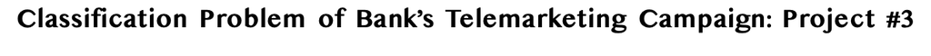

- **Student name:** Natalia Edelson
- **Student pace:** Flex
- **Scheduled project review date/time:** 12/12/22
- **Instructor name:** Morgan Jones
- **Blog post URL:** https://medium.com/@nataliagoncharov/classification-problem-of-banks-telemarketing-campaign-project-3-79633e899e3
- Importing Libraries
- Cleaning Data
- Explanatory Data Analysis
- Building Classification Models
- Evaluating Models
- Conclusions

#### Importing Libraries

```python
# Pandas and Matplotlib

import pandas as pd
import numpy as np
np.random.seed(0)
import seaborn as sns
import matplotlib.gridspec as gridspec
import matplotlib.pyplot as plt

#Sk-learn

from sklearn.model_selection import train_test_split
from sklearn.metrics import accuracy_score, confusion_matrix, f1_score, classification_report
from sklearn.neighbors import KNeighborsClassifier
from sklearn.linear_model import LogisticRegression
from sklearn.ensemble import RandomForestClassifier
from sklearn.metrics import precision_score, recall_score, accuracy_score
from sklearn.metrics import f1_score, confusion_matrix
from sklearn.metrics import plot_confusion_matrix
from sklearn.tree import DecisionTreeClassifier
from sklearn.metrics import auc, roc_curve, roc_auc_score, precision_recall_curve
from sklearn.model_selection import cross_val_score,KFold
from sklearn.metrics import f1_score,precision_score,recall_score, plot_confusion_matrix
from sklearn.metrics import plot_roc_curve,classification_report
import warnings
import random
from matplotlib import cm
from sklearn.model_selection import GridSearchCV
warnings.filterwarnings('ignore')
import time
import seaborn as sns
import seaborn
%matplotlib inline
from xgboost import XGBClassifier
from sklearn.model_selection import cross_validate
from sklearn.preprocessing import StandardScaler
import re
from sklearn.pipeline import Pipeline

from sklearn.preprocessing import OneHotEncoder
from sklearn.preprocessing import StandardScaler
from sklearn.compose import ColumnTransformer
from sklearn.svm import SVC
from tqdm.notebook import tqdm
import warnings
warnings.filterwarnings('ignore')
```

### Data Set - Variables Explanation

- `age` - age of the costumer (numeric)
- `job` type of job (categorical: 'admin.','blue-collar','entrepreneur','housemaid','management','retired','self-employed','services','student','technician','unemployed','unknown')
- `marital` marital status (categorical: 'divorced','married','single','unknown'; note: 'divorced' means divorced or widowed)
- `education` - (categorical:'basic.4y','basic.6y','basic.9y','high.school','illiterate','professional.course','university.degree','unknown')
- `default` - has credit in default? (categorical: 'no','yes','unknown')
- `housing` has housing loan? (categorical: 'no','yes','unknown')
- `loan` - has personal loan? (categorical: 'no','yes','unknown')
- `contact` - contact communication type (categorical: 'cellular','telephone')
- `month` -last contact month of year (categorical: 'jan', 'feb', 'mar', ..., 'nov', 'dec')
- `day_of_week` -last contact day of the week (categorical: 'mon','tue','wed','thu','fri')
- `duration` last contact duration, in seconds (numeric). Important note: this attribute highly affects the output

  target (e.g., if duration=0 then y='no'). Yet, the duration is not known before a call is performed. Also, after the end of the call y is obviously known. Thus, this input should only be included for benchmark purposes and should be discarded if the intention is to have a realistic predictive model.
- `campaign` -number of contacts performed during this campaign and for this client (numeric, includes last contact)
- `pdays:` - number of days that passed by after the client was last contacted from a previous campaign (numeric; 999 means client was not previously contacted)
- `previous` -number of contacts performed before this campaign and for this client (numeric)
- `poutcome` - outcome of the previous marketing campaign (categorical: 'failure','nonexistent','success')
- `emp.var.rate` - employment variation rate - quarterly indicator (numeric)
- `cons.price.idx` - consumer price index - monthly indicator (numeric)
- `cons.conf.idx` - consumer confidence index - monthly indicator (numeric)
- `uribor3m` - euribor 3 month rate - daily indicator (numeric)
- `nr.employed`- number of employees - quarterly indicator (numeric)
- `subscribed`- has the client subscribed a term deposit? (binary: 'yes','no')

```python
# Upload the data and view it

df_bank = pd.read_excel('bank.xlsx')
df_bank.head()
```

|  | age | job | marital | education | default | housing | loan | contact | month | day_of_week | ... | campaign | pdays | previous | poutcome | emp.var.rate | cons.price.idx | cons.conf.idx | euribor3m | nr.employed | y |
| --- | --- | --- | --- | --- | --- | --- | --- | --- | --- | --- | --- | --- | --- | --- | --- | --- | --- | --- | --- | --- | --- |
| 0 | 56 | housemaid | married | basic.4y | no | no | no | telephone | may | mon | ... | 1 | 999 | 0 | nonexistent | 1.1 | 93.994 | -36.4 | 4.857 | 5191.0 | no |
| 1 | 57 | services | married | high.school | unknown | no | no | telephone | may | mon | ... | 1 | 999 | 0 | nonexistent | 1.1 | 93.994 | -36.4 | 4.857 | 5191.0 | no |
| 2 | 37 | services | married | high.school | no | yes | no | telephone | may | mon | ... | 1 | 999 | 0 | nonexistent | 1.1 | 93.994 | -36.4 | 4.857 | 5191.0 | no |
| 3 | 40 | admin. | married | basic.6y | no | no | no | telephone | may | mon | ... | 1 | 999 | 0 | nonexistent | 1.1 | 93.994 | -36.4 | 4.857 | 5191.0 | no |
| 4 | 56 | services | married | high.school | no | no | yes | telephone | may | mon | ... | 1 | 999 | 0 | nonexistent | 1.1 | 93.994 | -36.4 | 4.857 | 5191.0 | no |

5 rows × 21 columns

```python
# Replace the name of the target variable from ‘y’ to ‘subscribed’ for clarity purposes.

df_bank = df_bank.rename({'y': 'subscribed'}, axis=1)  # new method
```

```python
# Check the overall data, data type, and number of entries. Spot null values.

df_bank.info()
```

```
<class 'pandas.core.frame.DataFrame'>
RangeIndex: 41188 entries, 0 to 41187
Data columns (total 21 columns):
 #   Column          Non-Null Count  Dtype
---  ------          --------------  -----
 0   age             41188 non-null  int64
 1   job             41188 non-null  object
 2   marital         41188 non-null  object
 3   education       41188 non-null  object
 4   default         41188 non-null  object
 5   housing         41188 non-null  object
 6   loan            41188 non-null  object
 7   contact         41188 non-null  object
 8   month           41188 non-null  object
 9   day_of_week     41188 non-null  object
 10  duration        41188 non-null  int64
 11  campaign        41188 non-null  int64
 12  pdays           41188 non-null  int64
 13  previous        41188 non-null  int64
 14  poutcome        41188 non-null  object
 15  emp.var.rate    41188 non-null  float64
 16  cons.price.idx  41188 non-null  float64
 17  cons.conf.idx   41188 non-null  float64
 18  euribor3m       41188 non-null  float64
 19  nr.employed     41188 non-null  float64
 20  subscribed      41188 non-null  object
dtypes: float64(5), int64(5), object(11)
memory usage: 6.6+ MB
```

```python
# Check the shape of the data 21 columns and 41,188 raws

df_bank.shape
```

```
(41188, 21)
```

```python
# List all the columns
df_bank.columns
```

```
Index(['age', 'job', 'marital', 'education', 'default', 'housing', 'loan',
       'contact', 'month', 'day_of_week', 'duration', 'campaign', 'pdays',
       'previous', 'poutcome', 'emp.var.rate', 'cons.price.idx',
       'cons.conf.idx', 'euribor3m', 'nr.employed', 'subscribed'],
      dtype='object')
```

### Cleaning the Data

#### Checking for Null Values

```python
# Using isnull method and sum it up
df_bank.isnull().sum()
```

```
age               0
job               0
marital           0
education         0
default           0
housing           0
loan              0
contact           0
month             0
day_of_week       0
duration          0
campaign          0
pdays             0
previous          0
poutcome          0
emp.var.rate      0
cons.price.idx    0
cons.conf.idx     0
euribor3m         0
nr.employed       0
subscribed        0
dtype: int64
```

```python
# Checking for object values

cat_df = df_bank.select_dtypes('object')
cat_df.head()
```

|  | job | marital | education | default | housing | loan | contact | month | day_of_week | poutcome | subscribed |
| --- | --- | --- | --- | --- | --- | --- | --- | --- | --- | --- | --- |
| 0 | housemaid | married | basic.4y | no | no | no | telephone | may | mon | nonexistent | no |
| 1 | services | married | high.school | unknown | no | no | telephone | may | mon | nonexistent | no |
| 2 | services | married | high.school | no | yes | no | telephone | may | mon | nonexistent | no |
| 3 | admin. | married | basic.6y | no | no | no | telephone | may | mon | nonexistent | no |
| 4 | services | married | high.school | no | no | yes | telephone | may | mon | nonexistent | no |

#### There are many unknown values and here I break down the percentage of the unknown values to see which ones would be okay to remove from the data.

```python
# Checking for the frequency of values of each column
for colname in cat_df.columns:
    try:
        print(colname, cat_df[colname].value_counts(normalize=True)[:10])
    except:
        print(colname, cat_df[colname].value_counts(normalize=True))

    print('\n')
```

```
job admin.           0.253035
blue-collar      0.224677
technician       0.163713
services         0.096363
management       0.070992
retired          0.041760
entrepreneur     0.035350
self-employed    0.034500
housemaid        0.025736
unemployed       0.024619
Name: job, dtype: float64


marital married     0.605225
single      0.280859
divorced    0.111974
unknown     0.001942
Name: marital, dtype: float64


education university.degree      0.295426
high.school            0.231014
basic.9y               0.146766
professional.course    0.127294
basic.4y               0.101389
basic.6y               0.055647
unknown                0.042027
illiterate             0.000437
Name: education, dtype: float64


default no         0.791201
unknown    0.208726
yes        0.000073
Name: default, dtype: float64


housing yes        0.523842
no         0.452122
unknown    0.024036
```

[output cut: 29 more lines]

```
wed    0.197485
tue    0.196416
fri    0.190031
Name: day_of_week, dtype: float64


poutcome nonexistent    0.863431
failure        0.103234
success        0.033335
Name: poutcome, dtype: float64


subscribed no     0.887346
yes    0.112654
Name: subscribed, dtype: float64
```

#### marital

**unknown 0.001942

#### education

**unknown 0.042027

#### default

**unknown 0.208726

#### housing yes

**unknown 0.024036

#### loan

**unknown 0.024036

```python
# The unkown values replaced with None and then dropped
unknown_col = ['job','marital', 'education', 'loan', 'housing']

for col in unknown_col:
    df_bank[col] = df_bank[col].replace('unknown', None)
    #df_bank[col] = df_bank[col].fillna(df[col].mode())
    df_bank.dropna(axis=0, subset=[col], inplace = True)
```

#### Handling Duplicates

```python
# Check for duplicates
df_bank.duplicated().sum()
```

```
12
```

```python
# Remove dupicates
df_bank = df_bank.drop_duplicates()
```

```python
# Doble check for duplicates

df_bank.duplicated().sum()
```

```
0
```

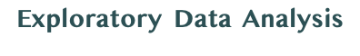

### Checking if the data is balanced

```python
# Plot the target variables in order to examine whether the data is imbalanced.

subscribe_vc = df_bank['subscribed'].value_counts()
subscribe_vc
```

```
no     36537
yes     4639
Name: subscribed, dtype: int64
```

[figure not shown]

```python
# Pie chart, where the slices will be ordered and plotted counter-clockwise:
# Reference: https://matplotlib.org/stable/gallery/pie_and_polar_charts/pie_features.html

labels = 'subscribed', 'unsubscribed'
sizes = df_bank['subscribed'].value_counts()
explode = (0, 0.1)  # only "explode" the 2nd slice

fig, ax = plt.subplots(1,2,figsize=(10,8))


ax[0].pie(sizes, explode=explode, labels=labels, autopct='%1.1f%%',
        shadow=True, startangle=90)
ax[0].axis('equal')  # Equal aspect ratio ensures that pie is drawn as a circle.
ax[0].set_title('Total Subscribed in Percentage', fontname='Times New Roman')


sns.countplot('subscribed', data=df_bank, ax=ax[1])

ax[1].set_title('Total Number of Subscribers', fontname='Times New Roman')
ax[1].set_ylabel('')

plt.show()
```

#### The data is imbalanced - only 11.3% costumes subscribed to the bank campaign. Later on, when we build the model, it will need to be dealt with. Most models can’t produce proper results when the data is imbalanced.

```python
# Check the distribution of data type


print("Data types and their frequency\n{}".format(df_bank.dtypes.value_counts()))
```

```
Data types and their frequency
object     11
int64       5
float64     5
dtype: int64
```

```python
# Check balance of target data

df_bank['subscribed'].value_counts()
```

```
no     36537
yes     4639
Name: subscribed, dtype: int64
```

```python
# Check for unique values for all the columns

df_bank.nunique()
```

```
age                 78
job                 11
marital              3
education            7
default              3
housing              2
loan                 2
contact              2
month               10
day_of_week          5
duration          1544
campaign            42
pdays               27
previous             8
poutcome             3
emp.var.rate        10
cons.price.idx      26
cons.conf.idx       26
euribor3m          316
nr.employed         11
subscribed           2
dtype: int64
```

### Exploring Continiuous Variables

```python
# Checking the distribution for the categorical variables c

df_bank.describe()
```

|  | age | duration | campaign | pdays | previous | emp.var.rate | cons.price.idx | cons.conf.idx | euribor3m | nr.employed |
| --- | --- | --- | --- | --- | --- | --- | --- | --- | --- | --- |
| count | 41176.00000 | 41176.000000 | 41176.000000 | 41176.000000 | 41176.000000 | 41176.000000 | 41176.000000 | 41176.000000 | 41176.000000 | 41176.000000 |
| mean | 40.02380 | 258.315815 | 2.567879 | 962.464810 | 0.173013 | 0.081922 | 93.575720 | -40.502863 | 3.621293 | 5167.034870 |
| std | 10.42068 | 259.305321 | 2.770318 | 186.937102 | 0.494964 | 1.570883 | 0.578839 | 4.627860 | 1.734437 | 72.251364 |
| min | 17.00000 | 0.000000 | 1.000000 | 0.000000 | 0.000000 | -3.400000 | 92.201000 | -50.800000 | 0.634000 | 4963.600000 |
| 25% | 32.00000 | 102.000000 | 1.000000 | 999.000000 | 0.000000 | -1.800000 | 93.075000 | -42.700000 | 1.344000 | 5099.100000 |
| 50% | 38.00000 | 180.000000 | 2.000000 | 999.000000 | 0.000000 | 1.100000 | 93.749000 | -41.800000 | 4.857000 | 5191.000000 |
| 75% | 47.00000 | 319.000000 | 3.000000 | 999.000000 | 0.000000 | 1.400000 | 93.994000 | -36.400000 | 4.961000 | 5228.100000 |
| max | 98.00000 | 4918.000000 | 56.000000 | 999.000000 | 7.000000 | 1.400000 | 94.767000 | -26.900000 | 5.045000 | 5228.100000 |

### Correlation

```python
# Create a function that captures the numerical variables.

numerical_var = [feature for feature in df_bank.columns if ((df_bank[feature].dtypes != 'O') & (feature not in ['deposit']))]
print('Number of continuous variables: ', len(numerical_var))

# visualise the numerical variables
df_bank_num = df_bank[numerical_var].head()


df_bank_num
```

```
Number of continuous variables:  10
```

|  | age | duration | campaign | pdays | previous | emp.var.rate | cons.price.idx | cons.conf.idx | euribor3m | nr.employed |
| --- | --- | --- | --- | --- | --- | --- | --- | --- | --- | --- |
| 0 | 56 | 261 | 1 | 999 | 0 | 1.1 | 93.994 | -36.4 | 4.857 | 5191.0 |
| 1 | 57 | 149 | 1 | 999 | 0 | 1.1 | 93.994 | -36.4 | 4.857 | 5191.0 |
| 2 | 37 | 226 | 1 | 999 | 0 | 1.1 | 93.994 | -36.4 | 4.857 | 5191.0 |
| 3 | 40 | 151 | 1 | 999 | 0 | 1.1 | 93.994 | -36.4 | 4.857 | 5191.0 |
| 4 | 56 | 307 | 1 | 999 | 0 | 1.1 | 93.994 | -36.4 | 4.857 | 5191.0 |

```
<function matplotlib.pyplot.show(close=None, block=None)>
```

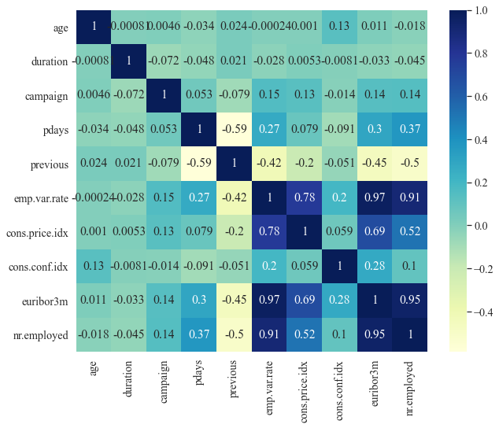

```python
# Checking the correlation metrics.

sns.set_theme(context='notebook', style='darkgrid', palette='deep', font='Times New Roman',
              font_scale= 1.3, color_codes=True, rc=None)

plt.figure(figsize=(10,8))

sns.heatmap(df_bank.corr(),cmap='YlGnBu',annot=True)



plt.show
```

```python
# Select upper triangle of correlation matrix, removing corr. higher than 0.95

corr_matrix = df_bank.corr()
upper = corr_matrix.where(np.triu(np.ones(corr_matrix.shape), k=1).astype(np.bool))

# Using a loop that would scan for high correlation 0.95 and
# would remove the respective variable.

to_drop = [column for column in upper.columns if any(upper[column] > 0.90)]

to_drop
```

```
['euribor3m', 'nr.employed']
```

#### These are the variables suggested 'euribor3m', 'nr.employed' - there are multiple strong relationships. ‘emp.var.rate’ and euribor3m as well as emp.car.rate with ‘nr.employed’.

#### I will remove ‘nr.employed’ and ‘emp.var.rate’ since ‘euribor3m’ is likely to be an important part of decision making for individuals when they decide to Subscribe or not to Subscribe.

```python
# Drop the respective features

to_drop = ['nr.employed', 'emp.var.rate']

df_bank.drop(to_drop, axis=1, inplace=True)
```

```python
# Scan the data again to verify that the variables were removed.
df_bank.head()
```

|  | age | job | marital | education | default | housing | loan | contact | month | day_of_week | duration | campaign | pdays | previous | poutcome | cons.price.idx | cons.conf.idx | euribor3m | subscribed |
| --- | --- | --- | --- | --- | --- | --- | --- | --- | --- | --- | --- | --- | --- | --- | --- | --- | --- | --- | --- |
| 0 | 56 | housemaid | married | basic.4y | no | no | no | telephone | may | mon | 261 | 1 | 999 | 0 | nonexistent | 93.994 | -36.4 | 4.857 | no |
| 1 | 57 | services | married | high.school | unknown | no | no | telephone | may | mon | 149 | 1 | 999 | 0 | nonexistent | 93.994 | -36.4 | 4.857 | no |
| 2 | 37 | services | married | high.school | no | yes | no | telephone | may | mon | 226 | 1 | 999 | 0 | nonexistent | 93.994 | -36.4 | 4.857 | no |
| 3 | 40 | admin. | married | basic.6y | no | no | no | telephone | may | mon | 151 | 1 | 999 | 0 | nonexistent | 93.994 | -36.4 | 4.857 | no |
| 4 | 56 | services | married | high.school | no | no | yes | telephone | may | mon | 307 | 1 | 999 | 0 | nonexistent | 93.994 | -36.4 | 4.857 | no |

```
<function matplotlib.pyplot.show(close=None, block=None)>
```

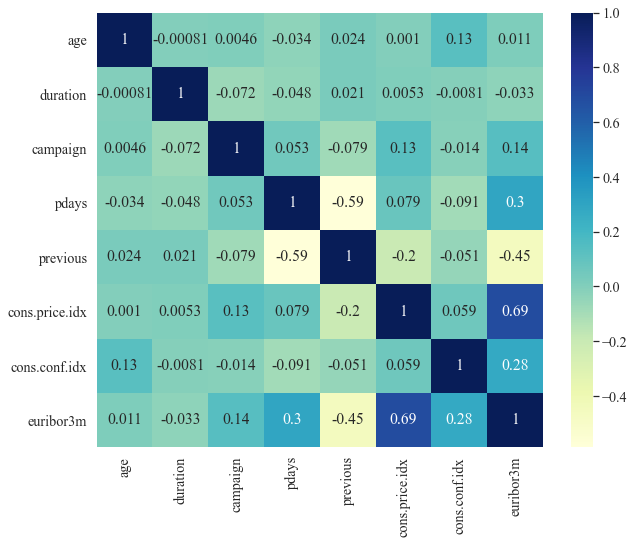

```python
# Checking again the correlation metrics.


sns.set_theme(context='notebook', style='darkgrid', palette='deep', font='Times New Roman',
              font_scale= 1.3, color_codes=True, rc=None)

plt.figure(figsize=(10,8))

sns.heatmap(df_bank.corr(),cmap='YlGnBu',annot=True)


plt.show
```

### Pairplot

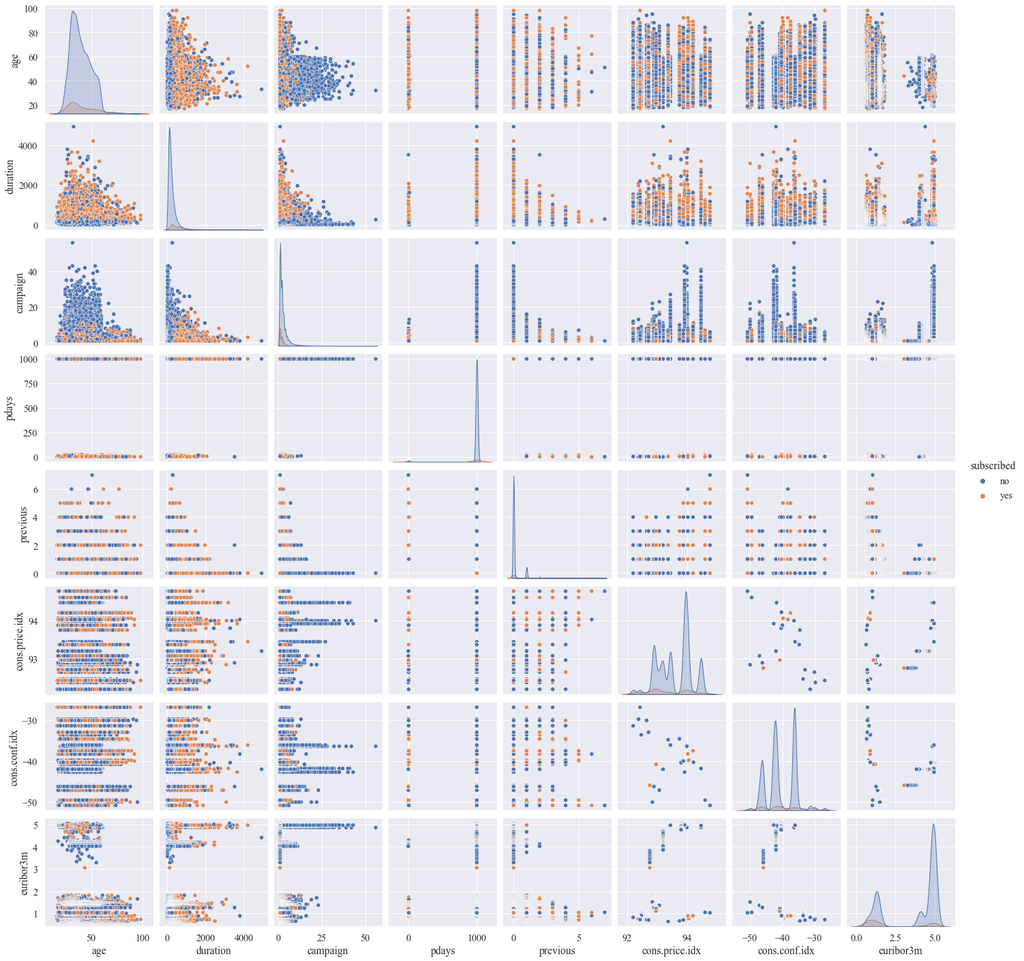

```python
# I will plot pairplot - using the hue ‘subscribed’ in order to spot any patterns.

plt.figure(figsize=(50,40))
sns.pairplot(df_bank, hue='subscribed')
#ax.legend()
```

#### Notes from pairplot - most variables are categorical. The continuous variables show various types of distribution.

### Histogram

```python
# Plot a histogram to take a closer look at the distribution.

#df_bank.hist(figsize= [20,10])
#plt.show()
```

### Visualize Numerical Variables

```python
# Here is another way to get the numerical data using _get_numeric _data function.

numeric_data = df_bank._get_numeric_data()
numeric_data.head()
```

|  | age | duration | campaign | pdays | previous | cons.price.idx | cons.conf.idx | euribor3m |
| --- | --- | --- | --- | --- | --- | --- | --- | --- |
| 0 | 56 | 261 | 1 | 999 | 0 | 93.994 | -36.4 | 4.857 |
| 1 | 57 | 149 | 1 | 999 | 0 | 93.994 | -36.4 | 4.857 |
| 2 | 37 | 226 | 1 | 999 | 0 | 93.994 | -36.4 | 4.857 |
| 3 | 40 | 151 | 1 | 999 | 0 | 93.994 | -36.4 | 4.857 |
| 4 | 56 | 307 | 1 | 999 | 0 | 93.994 | -36.4 | 4.857 |

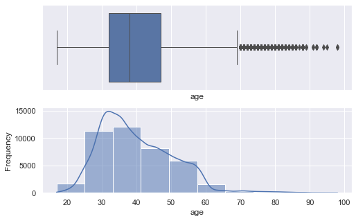

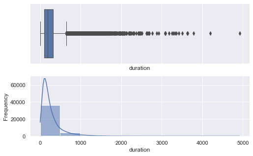

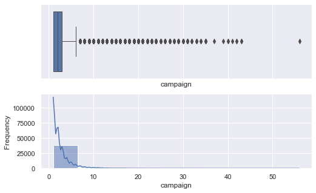

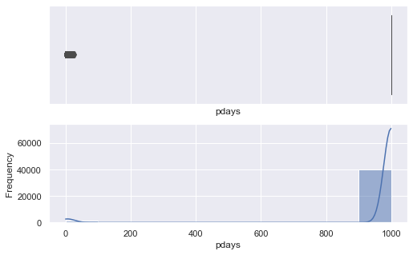

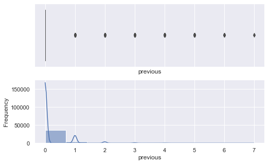

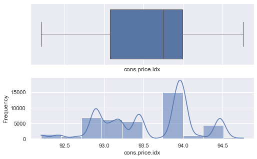

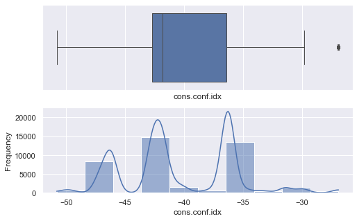

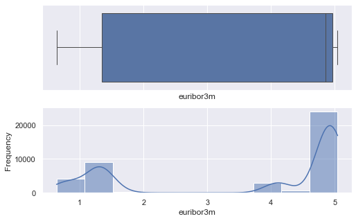

```python
# In this plot, we dive a little closer into the distribution of the numerical columns.

for i in numeric_data.columns:
    plt.figure()
    plt.tight_layout()
    sns.set(rc={"figure.figsize":(8, 5)})
    f, (ax_box, ax_hist) = plt.subplots(2, sharex=True)
    plt.gca().set(xlabel= i,ylabel='Frequency')
    sns.boxplot(numeric_data[i], ax=ax_box , linewidth= 1.0)
    sns.histplot(numeric_data[i], ax=ax_hist , bins = 10,kde=True)
```

#### Age: most of the population was from 30 to 50 years old.

#### Duration: most calls ranged from a minute to 8.5 minutes.

```python
# Using a lambda function  - I replace all the dots with the underlying symbol.


df_bank.columns = list(map(lambda x: x.replace('.', '_'),
                                 df_bank.columns))
```

```
Statistical Summary


Subscribed
                 count        mean         std     min      25%    50%  \
age             4639.0   40.912266   13.838838  17.000   31.000   37.0
duration        4639.0  553.256090  401.190736  37.000  253.500  449.0
pdays           4639.0  791.990946  403.439220   0.000  999.000  999.0
previous        4639.0    0.492779    0.860406   0.000    0.000    0.0
cons_price_idx  4639.0   93.354577    0.676592  92.201   92.893   93.2
cons_conf_idx   4639.0  -39.791119    6.139657 -50.800  -46.200  -40.4

                    75%       max
age              50.000    98.000
duration        741.500  4199.000
pdays           999.000   999.000
previous          1.000     6.000
cons_price_idx   93.918    94.767
cons_conf_idx   -36.100   -26.900
```

[figure not shown]

```python
# Plotting the numerical variables in relationship to subscribers versus
# people who did not subscribe.
print('Statistical Summary ')
print('\n')
print('Subscribed')
print(df_bank[df_bank['subscribed']=='yes'][['age','duration','pdays','previous',
                                             'cons_price_idx',
                                             'cons_conf_idx']].describe().transpose())
# print('--'*40)
# print('')

# Subplots of Numeric Features
sns.set_style('darkgrid')
fig = plt.figure(figsize = (18,15))
fig.subplots_adjust(hspace = .50)


ax1 = fig.add_subplot(421)
ax1.hist(df_bank[df_bank['subscribed']=='no'].age, bins = 25,
         label ='Did Not Subscribed', alpha = .50,edgecolor= 'black',color ='blue')
ax1.hist(df_bank[df_bank['subscribed']=='yes'].age, bins = 25,
         label = 'Subscribed', alpha = .50, edgecolor = 'black',color = 'lightgreen')
ax1.set_title('Costumer Age: Subscribed vs Non-Subscribed')
ax1.set_xlabel('Age')
ax1.set_ylabel('# Costumers')
ax1.legend(loc = 'upper right')

ax2 = fig.add_subplot(422)
ax2.hist(df_bank[df_bank['subscribed']=='no'].duration,
         bins = 25, label = 'Did Not Subscribed', alpha = .50,
         edgecolor ='black', color = 'blue')
ax2.hist(df_bank[df_bank['subscribed']=='yes'].duration,
         bins = 25, label = 'Subscribed', alpha = .50,
         edgecolor = 'black',color ='lightgreen')
ax2.set_title('Duration: Subscribed vs Non-Subscribed')
ax2.set_xlabel('Duration')
ax2.set_ylabel('# Costumers')
ax2.legend(loc = 'upper right')

ax3 = fig.add_subplot(423)


ax3.hist(df_bank[df_bank['subscribed']=='no'].pdays, bins = 50,
         label = 'Did Not Subscribed', alpha = .50, edgecolor ='black', color = 'blue')
ax3.hist(df_bank[df_bank['subscribed']=='yes'].pdays, bins = 50,
         label = 'Subscribed', alpha = .50, edgecolor = 'black',color ='lightgreen')
ax3.set_title('pdays: Subscribed vs Non-Subscribed')
ax3.set_xlabel('pdays')
ax3.set_ylabel('# Costumers')
ax3.legend(loc = 'upper right')


ax4 = fig.add_subplot(424)


ax4.hist(df_bank[df_bank['subscribed']=='no'].previous,
         bins = 50, label = 'Did Not Subscribed', alpha = .50, edgecolor ='black',
         color = 'blue')
ax4.hist(df_bank[df_bank['subscribed']=='yes'].previous,
         bins = 50, label = 'Subscribed', alpha = .50, edgecolor = 'black',
         color ='lightgreen')
ax4.set_title('previous: Subscribed vs Non-Subscribed')
ax4.set_xlabel('previous')
ax4.set_ylabel('# Costumers')
ax4.legend(loc = 'upper right')



ax5 = fig.add_subplot(425)

ax5.hist(df_bank[df_bank['subscribed']=='no'].cons_price_idx,
         bins = 50, label = 'Did Not Subscribed', alpha = .50,
         edgecolor ='black', color = 'blue')
ax5.hist(df_bank[df_bank['subscribed']=='yes'].cons_price_idx,
         bins = 50, label = 'Subscribed', alpha = .50, edgecolor = 'black',
         color ='lightgreen')
ax5.set_title('cons.price.idx: Subscribed vs Non-Subscribed')
ax5.set_xlabel('cons.price.idx')
ax5.set_ylabel('# Costumers')
ax5.legend(loc = 'upper right')



ax6 = fig.add_subplot(426)


ax6.hist(df_bank[df_bank['subscribed']=='no'].cons_conf_idx, bins = 50,
         label = 'Did Not Subscribed', alpha = .50, edgecolor ='black', color = 'blue')
ax6.hist(df_bank[df_bank['subscribed']=='yes'].cons_conf_idx, bins = 50,
         label = 'Subscribed', alpha = .50, edgecolor = 'black',color ='lightgreen')
ax6.set_title('euribor3m: Subscribed vs Non-Subscribed')
ax6.set_xlabel('euribor3m')
ax6.set_ylabel('# Costumers')
ax6.legend(loc = 'upper right')

ax3.legend()

plt.show()
```

#### * Certain indices are showing a small increase in likelihood.

```python
# Plotting specific ages to see which ones subscribed the most.

def myplot(colname):

    df_plot = df_bank.groupby(['subscribed',
                               colname]).size().reset_index().pivot(columns='subscribed',
                                                                    index=colname, values=0)
    df_plot['total'] = df_plot.sum(axis=1)
#     df_plot['no'] = df_plot['no']*100/df_plot['total']
#     df_plot['yes'] = df_plot['yes']*100/df_plot['total']
    df_plot.drop('total',axis=1,inplace=True)
#     df_plot.sort_values('yes',ascending=False,inplace=True)

#     fig.set_size_inches(20, 8)


    df_plot.plot(kind='bar', stacked=True, figsize=(30,12))


    plt.xlabel(colname, fontsize=32)
    plt.ylabel('Count', fontsize=32)
    plt.xticks(rotation = 90,fontsize=26)
    plt.yticks(rotation = 0,fontsize=24)
    plt.grid(True, color = "white", linewidth = "1.4", linestyle = "-")
    plt.legend(loc=2, prop={'size': 22})

    #ax.set_title('Age Count Distribution', fontsize=28)

    sns.despine()
```

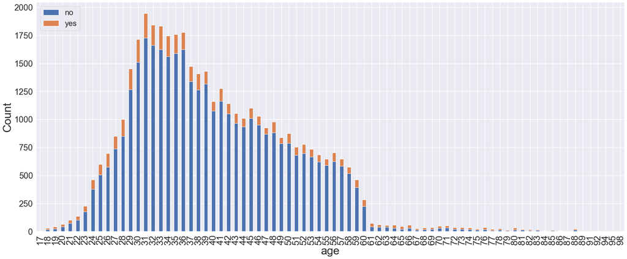

```python
myplot('age')
```

#### I decided to create ranges of ages since it will give a better sense of what group to target.

```python
# Here are the  bins  based on the values observed above.
# 5 values will result in 4 bins

bins = [17, 35, 36, 55, 56, 65, 66, 98]


#We'll pd.cut method to separate data into bins.
df_bank['bins_age'] = pd.cut(df_bank['age'], bins)

# I will use .cat.as_unordered() method transforming the data to
# ordered categories.
# bins_age_built = bins_yr_built.cat.as_unordered()
# bins_yr_built.head()
```

```python
# Rechaeck data set for bins column.

df_bank.head()
```

|  | age | job | marital | education | default | housing | loan | contact | month | day_of_week | duration | campaign | pdays | previous | poutcome | cons_price_idx | cons_conf_idx | euribor3m | subscribed | bins_age |
| --- | --- | --- | --- | --- | --- | --- | --- | --- | --- | --- | --- | --- | --- | --- | --- | --- | --- | --- | --- | --- |
| 0 | 56 | housemaid | married | basic.4y | no | no | no | telephone | may | mon | 261 | 1 | 999 | 0 | nonexistent | 93.994 | -36.4 | 4.857 | no | (55, 56] |
| 1 | 57 | services | married | high.school | unknown | no | no | telephone | may | mon | 149 | 1 | 999 | 0 | nonexistent | 93.994 | -36.4 | 4.857 | no | (56, 65] |
| 2 | 37 | services | married | high.school | no | yes | no | telephone | may | mon | 226 | 1 | 999 | 0 | nonexistent | 93.994 | -36.4 | 4.857 | no | (36, 55] |
| 3 | 40 | admin. | married | basic.6y | no | no | no | telephone | may | mon | 151 | 1 | 999 | 0 | nonexistent | 93.994 | -36.4 | 4.857 | no | (36, 55] |
| 4 | 56 | services | married | high.school | no | no | yes | telephone | may | mon | 307 | 1 | 999 | 0 | nonexistent | 93.994 | -36.4 | 4.857 | no | (55, 56] |

```python
# Assigning a name for a demographic age group for each bin.

df_bank = df_bank.assign(age_group=pd.cut(df_bank['age'], bins=[17, 35,  55,  65, 98],
                             right=False, labels = ['Young_Adults','Middle_Aged Adults',
                                            'Older_Adults','Seniors']))
```

```python
# Make an independent copy so I won't need to run the notebook from the top.
df_bank_copy = df_bank.copy()
```

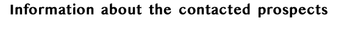

#### I will create a function that will calculate each variable’s distribution and plot the information. It is important to see the sample of people who have been contacted. In instances where the sample is low (e.g. less than 100), I will omit to calculate the percentage change since it will be insignificantnt.

```python
# Building a “countplot” function that will plot the distribution for each categorical variable.

def countplot(colname):
    fig, ax = plt.subplots()
    fig.set_size_inches(6, 4)
    sns.countplot(x = colname, data = df_bank, order = df_bank[colname].value_counts().index,
                  palette = "coolwarm_r")
    ax.set_xlabel(colname, fontsize=16)
    ax.set_ylabel('Count', fontsize=16)
    plt.xticks(rotation = 50,fontsize=16)
    plt.yticks(rotation = 0,fontsize=16)
    ax.set_title('Distribution', fontsize=16)
    ax.tick_params(labelsize=14)
    sns.despine()
```

```python
# Count the age groups
df_bank["age_group"].value_counts()
```

```
Middle_Aged Adults    22197
Young_Adults          14751
Older_Adults           3566
Seniors                 660
Name: age_group, dtype: int64
```

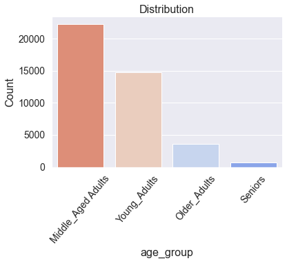

```python
countplot('age_group')
```

#### The majority of the people contacted were middle-aged and young adults. Even though only 660 senor people were contacted, there are still enough sample of people to draw information about their behavior.

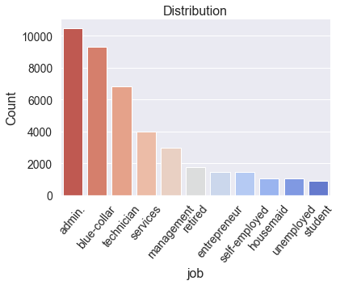

```python
countplot('job')
```

#### The sample of the population that was mainly included in the job category was: Admin, Blue-color Technician.

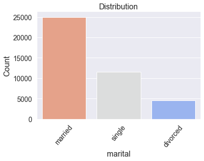

```python
countplot('marital')
```

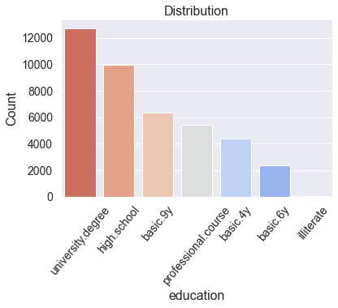

```python
countplot('education')
```

#### There were twice as many individuals with a university degree who were contacted than individuals who had 9 years of schooling.

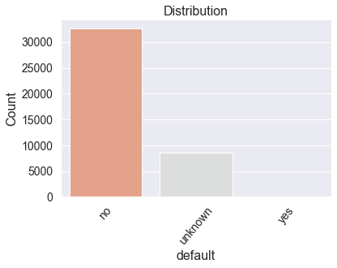

```python
countplot('default')
```

#### Most individuals who were contacted did not default on their credit.

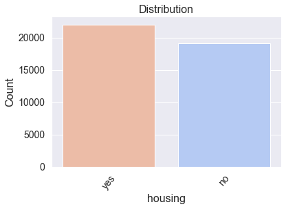

```python
countplot('housing')
```

#### Individuals with or without housing loans were contacted in a similar population size.

```python
df_bank['month'].value_counts()
```

```
may    13767
jul     7169
aug     6176
jun     5318
nov     4100
apr     2631
oct      717
sep      570
mar      546
dec      182
Name: month, dtype: int64
```

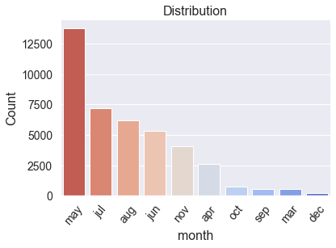

```python
countplot('month')
```

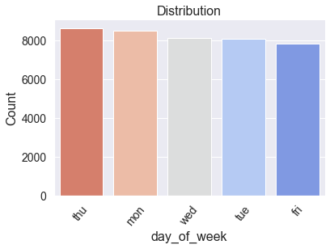

```python
countplot('day_of_week')
```

#### Individuals were contacted during the week, (roughly equaliy distributed Mon. to Fri.)

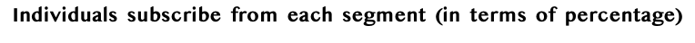

```python
# Building a function that first extracts a data set with a given column and
# a subscribed column.

def statPlot(colname):

    ############# crarte df ################
    df = df_bank[[colname,'subscribed']]

    df  = df.groupby([colname,
                              'subscribed']).size().reset_index().pivot(columns='subscribed',
                                                                        index=colname,
                                                                    values=0)


    df['percentage_of_subscribers']= df['yes']*100/(df['no']+ df['yes'])
    # df_job['percentage_of_unsubscribers']= df_job['no']/(df_job['no']+ df_job['yes'])
    df.dropna(inplace=True)
    df= df.sort_values('percentage_of_subscribers').reset_index()
    df[colname] = df[colname].astype('str')

    ##### PLOT ####################
    plt.figure(figsize=(15,5))
    ax = sns.barplot(df[colname],df['percentage_of_subscribers'],
                     palette="vlag")
    for bars in ax.containers:
        ax.bar_label(bars, fmt="%.2f%%")
    plt.xticks(rotation = 50)
    plt.show()
```

```python
# list all the columns
list(df_bank)
```

```
['age',
 'job',
 'marital',
 'education',
 'default',
 'housing',
 'loan',
 'contact',
 'month',
 'day_of_week',
 'duration',
 'campaign',
 'pdays',
 'previous',
 'poutcome',
 'cons_price_idx',
 'cons_conf_idx',
 'euribor3m',
 'subscribed',
 'bins_age',
 'age_group']
```

```python
# Creating a list so it would be easy to grab to run it in the function’s loop.


imp_col= ['job',
 'marital',
 'education',
 'default',
 'housing',
 'loan',
 'contact',
 'month',
 'day_of_week',
 'campaign',
'age_group']
```

```python
df_bank[['job', 'subscribed']].value_counts()
```

```
job            subscribed
admin.         no            9138
blue-collar    no            8670
technician     no            6065
services       no            3674
management     no            2618
admin.         yes           1361
entrepreneur   no            1342
retired        no            1306
self-employed  no            1283
housemaid      no             959
unemployed     no             877
technician     yes            737
blue-collar    yes            642
student        no             605
retired        yes            438
management     yes            334
services       yes            324
student        yes            277
self-employed  yes            149
unemployed     yes            145
entrepreneur   yes            124
housemaid      yes            108
dtype: int64
```

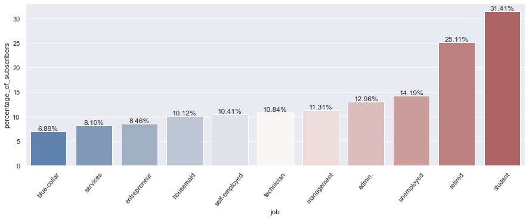

```python
# Running functionfor the 'job' column

statPlot('job')
```

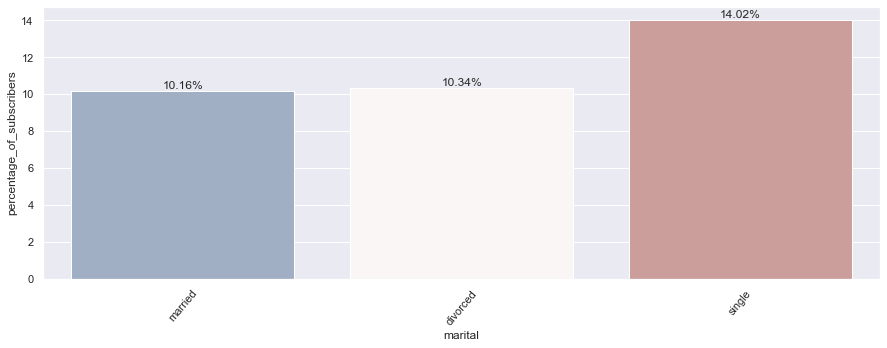

```python
# Running functionfor the 'marital' column

statPlot('marital')
```

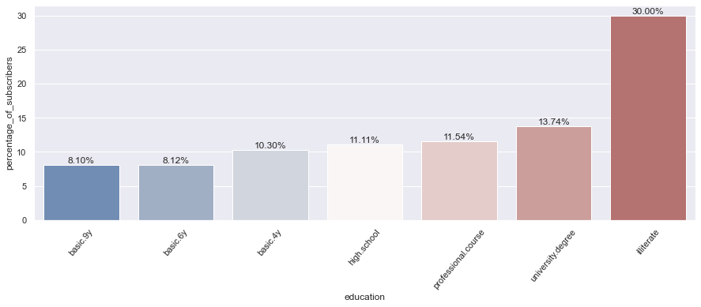

```python
# Running functionfor the 'education' column

statPlot('education')
```

```python
# String to be searched in start of string
# https://www.geeksforgeeks.org/python-pandas-series-str-count/

search ="illiterate"

# count of occurrence of a and creating new column
df_bank["count"]= df_bank["education"].str.count(search, re.I)

# display
df_bank["count"].value_counts()
```

```
0    41156
1       20
Name: count, dtype: int64
```

```python
print("of Illiterate:")
#20/41156 = 0.00048
20 *.3
```

```
of Illiterate:
```

```
6.0
```

```python
df_bank['education']
```

```
0                   basic.4y
1                high.school
2                high.school
3                   basic.6y
4                high.school
                ...
41183    professional.course
41184    professional.course
41185      university.degree
41186    professional.course
41187    professional.course
Name: education, Length: 41176, dtype: object
```

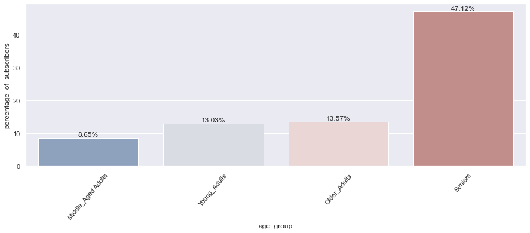

```python
# Running function for the 'age_group' column

statPlot('age_group')
```